# Foam Rolling your Way through the Tidyverse

Marc Campo Extended by Kingsley Kojo Kpoku

2026-11-12

# Data Source and Overview

Data were taken from an experimental cross-over study of the effect of foam rolling (FR) on flexibility in a study in college athletes by Hirose et al.<sup>1</sup> The authors made the data available for public download.

Twenty participants had flexibility measured, performed foam rolling (with a soccer ball), and then had their flexibility measured immediately after and 10 minutes after rolling. Foam rolling was performed with a soccer ball on a force plate at low (15-25% body weight) and high (45-55%) pressure. Flexibility was assessed with the Posterior Straight Leg Test (PSLR).

In the data there are different rows for each participant at each intervention level but the pre, post and 10-minute post are in wide format. We will use tidyr and dplyr to pull out the PSLR test data (which is what we use in the clinic more frequently), then summarize with dplyr and then convert to fully long format with tidyr.

## Load the Data

Only the second sheet is needed.

```r
data <- readxl::read_excel(
  file.choose(),
  sheet = "tab2"
)


data
```

```
## # A tibble: 120 × 7
##       ID Sex   `Type of measurment` Condition   Pre  Post Post10
##    <dbl> <chr> <chr>                <chr>     <dbl> <dbl>  <dbl>
##  1     1 M     PSLR                 CTRL       73    76.5   77
##  2     2 M     PSLR                 CTRL       95    95.5   96.5
##  3     3 M     PSLR                 CTRL      108.  106    104.
##  4     9 M     PSLR                 CTRL       78    84     80
##  5    10 M     PSLR                 CTRL       71.5  70     69.5
##  6    11 M     PSLR                 CTRL       74    74.5   68
##  7    13 M     PSLR                 CTRL       72.5  69     71.5
##  8    15 M     PSLR                 CTRL       89    89     86.5
##  9    16 M     PSLR                 CTRL       77.5  71     77
## 10    19 M     PSLR                 CTRL       80.5  75.5   77.5
## # ℹ 110 more rows
```

## Change Variable Names

Since the data were in Excel, some of the variables have names with spaces.

```r
# Use rename instead of creating a new column
data <- data %>%
  rename(Measure = `Type of measurment`,
  )
```

## Using dplyr to filter the data

Here we select only the rows related to one of the two flexibility tests - the posterior straight leg raise (PSLR). This test is more commonly used in the clinic to assess hamstring length. The filter command selects rows.

```r
# filter only those rows that measure ROM with the PSLR test.
data <- data %>%
  filter(Measure=="PSLR")
```

## Using dplyr to summarize the measures

The research questions related to differences between conditions and sex. In the code below you will see code to summarize the mean and SD in ROM measures grouped by condition, sex and then both.

In some cases, other non-dplyr commands like psych::describe may offer statistics that are not available through dplyr summarize like skew or IQR. psych::describe output cannot be pipped into a dplyr command directly but a workaround would make for a great extension assignment!*

The results will be easier to evaluate when I plot them but we can see from the descriptive statistics that the foam rolling seemed to help and that women had a greater increase in ROM than men.

```r
# Use dplyr to group by condition and summarize with means and sds
data %>%
  group_by(Condition) %>%
  summarize(
    mean_pre=mean(Pre),
    sd_pre = sd(Pre),
    mean_post = mean(Post),
    sd_post = sd(Post),
    mean_post10 = mean(Post10),
    sd_post10 = sd(Post10)
  )
```

```
## # A tibble: 3 × 7
##   Condition mean_pre sd_pre mean_post sd_post mean_post10 sd_post10
##   <chr>        <dbl>  <dbl>     <dbl>   <dbl>       <dbl>     <dbl>
## 1 CTRL          83.9   10.6      82.9    11.0        82.9      10.4
## 2 High          81.4   10.8      90.3    12.1        90.9      11.0
## 3 Low           82.6   11.4      88.3    11.2        88.9      10.7
```

```r
# Group by sex and list out summary statistics
data %>%
  group_by(Sex) %>%
  summarize(
    mean_pre=mean(Pre),
    sd_pre = sd(Pre),
    mean_post = mean(Post),
    sd_post = sd(Post),
    mean_post10 = mean(Post10),
    sd_post10 = sd(Post10)
  )
```

```
## # A tibble: 2 × 7
##   Sex   mean_pre sd_pre mean_post sd_post mean_post10 sd_post10
##   <chr>    <dbl>  <dbl>     <dbl>   <dbl>       <dbl>     <dbl>
## 1 F         84.7   9.18      90.3    11.1        90.8      9.58
## 2 M         80.6  12.0       84.0    11.7        84.3     11.7
```

```r
# Group by both sex and condition
data %>%
  group_by(Condition, Sex) %>%
  summarize(
    mean_pre=mean(Pre),
    sd_pre = sd(Pre),
    mean_post = mean(Post),
    sd_post = sd(Post),
    mean_post10 = mean(Post10),
    sd_post10 = sd(Post10)
  )
```

```
## # A tibble: 6 × 8
## # Groups:   Condition [3]
##   Condition Sex   mean_pre sd_pre mean_post sd_post mean_post10 sd_post10
##   <chr>     <chr>    <dbl>  <dbl>     <dbl>   <dbl>       <dbl>     <dbl>
## 1 CTRL      F         86.0   9.51      84.7    9.84        85.2      9.10
## 2 CTRL      M         81.8  11.8       81.1   12.3         80.7     11.6
## 3 High      F         84     9.08      95.4   11.1         94.8      9.57
## 4 High      M         78.8  12.2       85.2   11.4         87.0     11.5
## 5 Low       F         84.1   9.79      90.8   10.5         92.6      8.02
## 6 Low       M         81.1  13.1       85.8   11.9         85.2     12.1
```

## Pivot Longer

To visualize the data set and then test for significant differences, the long format allows for easier plotting and testing.

I am naming the measure (values_to) - “ROM” which stands for Range of Motion. The indicator label in each row (names_to) will label the row as pre, post or 10 minutes post-rolling.

As you can see from the head, all columns and rows look good.

```r
# Change from semi-wide to long format and label each condition in the rows.  Name the column with the PSLR data 'ROM'
data_long <- data %>%
  pivot_longer(cols=c("Pre", "Post", "Post10"), values_to = "ROM", names_to = "Time")
head(data_long)
```

```
## # A tibble: 6 × 6
##      ID Sex   Measure Condition Time     ROM
##   <dbl> <chr> <chr>   <chr>     <chr>  <dbl>
## 1     1 M     PSLR    CTRL      Pre     73
## 2     1 M     PSLR    CTRL      Post    76.5
## 3     1 M     PSLR    CTRL      Post10  77
## 4     2 M     PSLR    CTRL      Pre     95
## 5     2 M     PSLR    CTRL      Post    95.5
## 6     2 M     PSLR    CTRL      Post10  96.5
```

## Visualization and Testing

The long data format makes it easier to plot. With a smaller data set, we can squeeze a lot of data into the plots without overwhelming the reader. Using ggplot, we can plot by both condition and sex.

- The plots include box plots for each condition or sex across the 3 time periods.
- The large dots are the means.
- The jittered points are the individual data points.
  - When overlaying a jitter plot over a box plot, outlier.shape must be set to NA or *R* will duplicate outlying data points.

### By Condition

The first plot is by condition. You can see that flexibility went up in the high and low pressure conditions and not as much in the control condition. High pressure resulted in the highest gains and which seemed to persist at 10 minutes post.

Two participants may especially have influenced these results. There was one participant that started with a lot of ROM and stayed that way under the high condition. There was also one participant who started low, went a little lower, and then just leveled off a bit under the control condition. Although the chart is busy, you can see the variability that would not be apparent by examining just box plots, or means.

Note that males and females are both included within each condition. And that each condition includes the same 20 participants because this was a crossover.

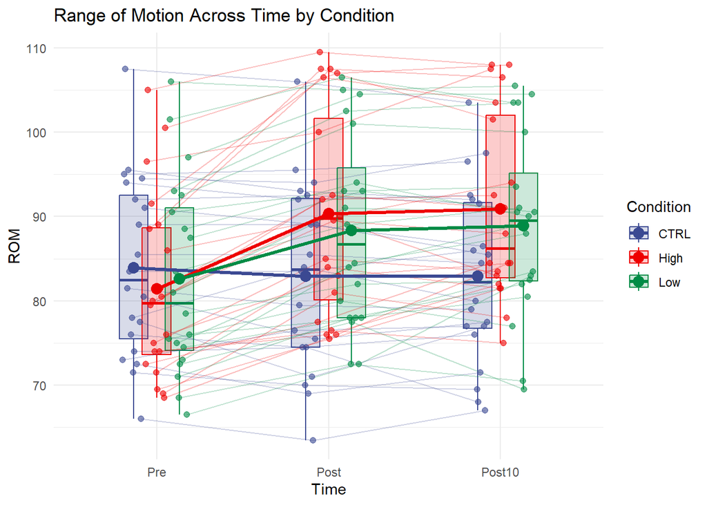

```r
# Make sure Time is ordered correctly because the chart will list them alphabetically - very annoying.
data_long$Time <- factor(
  data_long$Time,
  levels = c("Pre", "Post", "Post10")
)

# Specify position so we can repeatedly refer back to it and keep things consisent.
pd_condition <- position_dodge(width = 0.4)

ggplot(data_long, aes(x = Time, y = ROM,
                      color = Condition,
                      fill = Condition)) +

# Boxplots by Condition at each time point
  geom_boxplot(
    aes(group = interaction(Time, Condition)),
    width = 0.5,
    alpha = 0.2,
    position = pd_condition,
    outlier.shape = NA
  ) +

# Individual participant lines within each Condition
  geom_line(
    aes(group = interaction(ID, Condition)),
    position = pd_condition,
    alpha = 0.25,
    linewidth = 0.4
  ) +

# Individual participant points, aligned with the lines
  geom_point(
    aes(group = interaction(ID, Condition)),
    position = pd_condition,
    alpha = 0.6,
    size = 1.8
  ) +

# Mean line by Condition - this connects the overall mean dots.
  stat_summary(
    aes(group = Condition),
    fun = mean,
    geom = "line",
    position = pd_condition,
    linewidth = 1.2
  ) +

  # Mean points by Condition - this gives us the mean dots by condition.
  stat_summary(
    aes(group = Condition),
    fun = mean,
    geom = "point",
    position = pd_condition,
    size = 3.5
  ) +

  scale_color_aaas() +
  scale_fill_aaas() +

# Fix and Fancy labels
  labs(
    title = "Range of Motion Across Time by Condition",
    x = "Time",
    y = "ROM",
    color = "Condition",
    fill = "Condition"
  ) + theme_minimal()
```

### By Sex

You can see that Female scores went up a bit more than Male scores and that the initial changes persisted.

Note that in this plot, each individual data point represents the *average* of the 3 conditions in each sex group. So the data points do not match what you would see above.

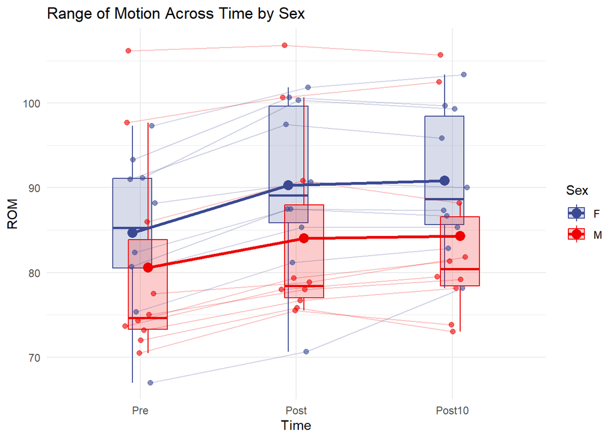

```r
# This plot requires us to average the values for each participant accross three conditions within each time point.
data_sex_plot <- data_long %>%
  group_by(ID, Sex, Time) %>%
  summarize(
    ROM = mean(ROM, na.rm = TRUE),
    .groups = "drop"
  )
# This plot requires a different position_dodge to avoid crowding.
pd_sex <- position_dodge(width = 0.2)

ggplot(data_sex_plot, aes(x = Time, y = ROM,
                          color = Sex,
                          fill = Sex)) +

# Boxplots by Sex at each time point - don't forget to omit the outliers becuase of the individual points plotted.
  geom_boxplot(
    aes(group = interaction(Time, Sex)),
    width = 0.5,
    alpha = 0.2,
    position = pd_sex,
    outlier.shape = NA
  ) +

# Individual participant lines connecting their average values within condition.
  geom_line(
    aes(group = ID),
    position = pd_sex,
    alpha = 0.25,
    linewidth = 0.4
  ) +

# Individual participant points, aligned with the lines
  geom_point(
    aes(group = ID),
    position = pd_sex,
    alpha = 0.6,
    size = 1.8
  ) +
# Connect means with a line
      stat_summary(
    aes(group = Sex),
    fun = mean,
    geom = "line",
    position = pd_sex,
    linewidth = 1.2
  ) +
# Plot means
   stat_summary(
    aes(group = Sex),
    fun = mean,
    geom = "point",
    position = pd_sex,
    size = 3.5
  ) +

  scale_color_aaas() +
  scale_fill_aaas() +
# Fix and Fancy!
  labs(
    title = "Range of Motion Across Time by Sex",
    x = "Time",
    y = "ROM",
    color = "Sex",
    fill = "Sex"
  ) +

  theme_minimal()
```